# Lab3_Classification

```r
t.test.pred.summary<-summary.pred(t.table)
t.test.pred.summary
```

**$FPR**

0.24

**$TPR**

0.71

**$PPR**

0.7

**$NPR**

0.77

Next, we consider whether pruning the tree might lead to improved results. The function `cv.tree()` performs cross-validation in order to `cv.tree()` determine the optimal level of tree complexity; cost complexity pruning is used in order to select a sequence of trees for consideration. We use the argument `FUN=prune.misclass` in order to indicate that we want the classification error rate to guide the cross-validation and pruning process, rather than the default for the `cv.tree()` function, which is deviance. The `cv.tree()` function reports the number of terminal nodes of each tree considered (`size`) as well as the corresponding error rate and the value of the cost-complexity parameter used (`k`, which corresponds to $\alpha$(Lokk formula in Lecture Notes)).

```r
set.seed (3)
cv.carseats =cv.tree(tree.carseats ,FUN=prune.misclass )
names(cv.carseats )
cv.carseats
```

1. 'size'

2. 'dev'

3. 'k'

4. 'method'

```
$size
[1] 21 19 13  9  5  2  1

$dev
[1] 71 71 66 58 55 71 97

$k
[1]      -Inf  0.000000  1.000000  1.500000  2.500000  8.333333 26.000000

$method
[1] "misclass"

attr(,"class")
[1] "prune"         "tree.sequence"
```

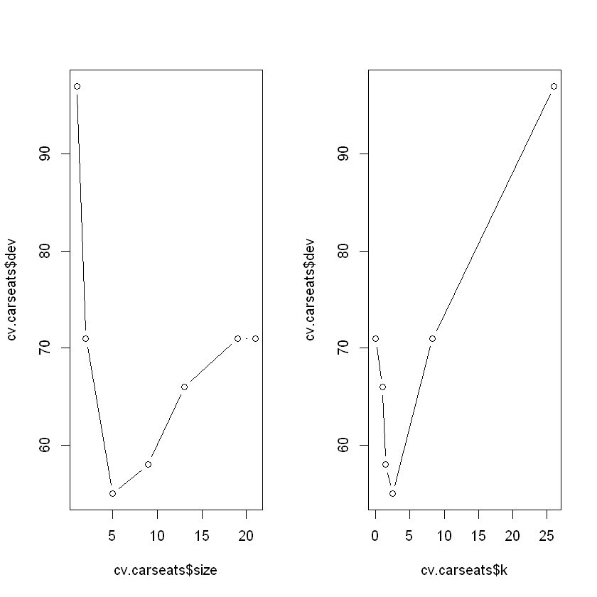

```r
par(mfrow =c(1,2))
plot(cv.carseats$size ,cv.carseats$dev ,type="b")
plot(cv.carseats$k ,cv.carseats$dev ,type="b")
```

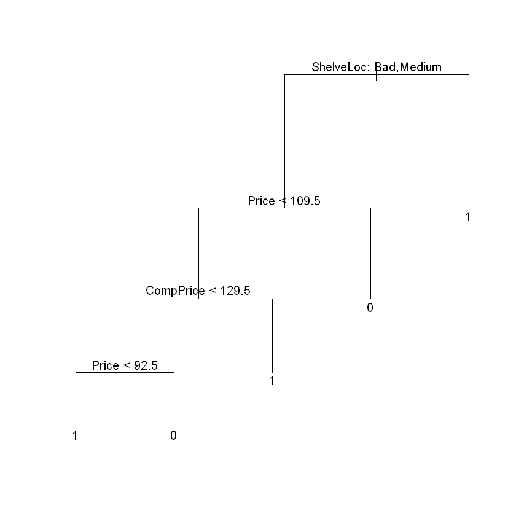

```r
prune.carseats =prune.misclass (tree.carseats ,best =5)
plot(prune.carseats )
text(prune.carseats ,pretty =0)
```

How well does this pruned tree perform on the test data set? Once again, we apply the `predict()` function.

```r
tree.pred=predict (prune.carseats , test ,type="class")
t.table<-table(tree.pred ,test$High)
t.table
```

```
tree.pred  0  1
        0 64 18
        1 19 49
```

```r
(64+49)/150
```

0.753333333333333

```r
t.test.pred.summary<-summary.pred(t.table)
t.test.pred.summary
```

**$FPR**

0.22

**$TPR**

0.72

**$PPR**

0.73

**$NPR**

0.77

Now $75\%$ of the test observations are correctly classified, so not only has the pruning process produced a more interpretable tree, but it has also improved the classification accuracy.

### Bagging

```r
dim(train)
```

1. 250

2. 12

```r
library(randomForest)
set.seed (1)
bag.model =randomForest(High∼.,data=train ,
mtry=11, importance =TRUE)
bag.model
```

```
Call:
 randomForest(formula = High ~ ., data = train, mtry = 11, importance = TRUE)
               Type of random forest: classification
                     Number of trees: 500
No. of variables tried at each split: 11

        OOB estimate of  error rate: 0.4%
Confusion matrix:
    0  1 class.error
0 152  1 0.006535948
1   0 97 0.000000000
```

```r
bag.pred = predict (bag.model ,newdata =test)
```

```r
b.table<-table(bag.pred ,test$High)
b.table
```

```
bag.pred  0  1
       0 83  0
       1  0 67
```

```r
(83+67)/150
```

1

```r
b.test.pred.summary<-summary.pred(b.table)
b.test.pred.summary
```

**$FPR**

0

**$TPR**

1

**$PPR**

1

**$NPR**

1

#### Random Forest

```r
set.seed (1)
rf.model =randomForest(High∼.,data=train ,
mtry=4, importance =TRUE)
rf.model
pred.rf = predict (rf.model,newdata =test)
```

```
Call:
 randomForest(formula = High ~ ., data = train, mtry = 4, importance = TRUE)
               Type of random forest: classification
                     Number of trees: 500
No. of variables tried at each split: 4

        OOB estimate of  error rate: 0.4%
Confusion matrix:
    0  1 class.error
0 152  1 0.006535948
1   0 97 0.000000000
```

```r
rf.table<-table(pred.rf ,test$High)
rf.table
```

```
pred.rf  0  1
      0 83  0
      1  0 67
```